# Analisi sulla serie storica dei decessi in lombardia

Prima di tutto importo il file relativo ai decessi in Lombardia e lo trasformo in serie temporale, inoltre importo le librerie necessarie alla gestione.

Visto il dato che stiamo cercando, utilizziamo solamente i dati mensili, prendendo la somma dei decessi suddivisi per mese e dividendo per il numero di giorni, in modo da eliminare i fattori legati al fatto che alcuni mesi sono più lunghi di altri.

```r
if(!require(tidyverse)) install.packages("tidyverse")
if(!require(xts)) install.packages("xts")
if(!require(lubridate)) install.packages("lubridate")
if(!require(forecast)) install.packages("forecast")
if(!require(tseries)) install.packages("tseries")
db <- read_csv("data/lombardia_giorno_totale.csv")
```

```
5 parsing failures.
row col  expected    actual                               file
137  -- 5 columns 6 columns 'data/lombardia_giorno_totale.csv'
281  -- 5 columns 6 columns 'data/lombardia_giorno_totale.csv'
372  -- 5 columns 6 columns 'data/lombardia_giorno_totale.csv'
420  -- 5 columns 6 columns 'data/lombardia_giorno_totale.csv'
571  -- 5 columns 6 columns 'data/lombardia_giorno_totale.csv'
```

```r
db_m <- db %>%
  mutate(D_per_month = days_in_month(DATA)) %>%
  group_by(MONTH = cut(DATA, "month")) %>%
  summarise(DECESSI_Pday = sum(DECESSI/D_per_month))
decessi_m_ts <- as.xts(db_m$DECESSI_Pday, order.by = as.Date(db_m$MONTH))["/2019"]
```

Ora tento con un modello auto-arima, prevedendo il numero di decessi al giorno per marzo.

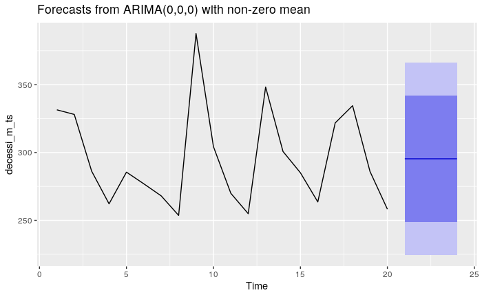

```r
model1 <- auto.arima(decessi_m_ts)
points <- forecast(model1, h = 4)
points %>% autoplot()
```

Si può vedere che non va affatto bene. Proviamo manualmente.

Per prima cosa si testa la stazionarità della serie così com’è.

```r
adf.test(decessi_m_ts)
```

```
p-value smaller than printed p-value
```

```
    Augmented Dickey-Fuller Test

data:  decessi_m_ts
Dickey-Fuller = -4,8164, Lag order = 2, p-value = 0,01
alternative hypothesis: stationary
```

Pare che la serie sia già stazionaria.

Proviamo ad osservare le funzioni di correlazione parziale e di autocorrelazione,

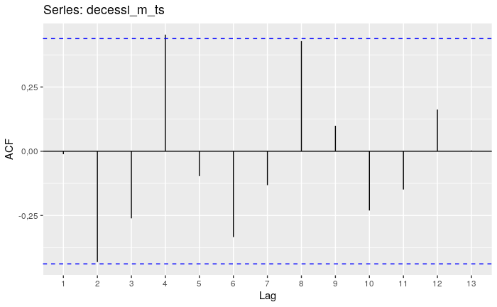

```r
ggAcf(decessi_m_ts)
```

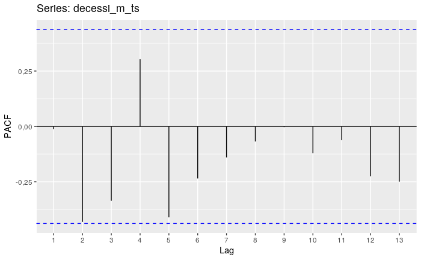

```r
ggPacf(decessi_m_ts)
```

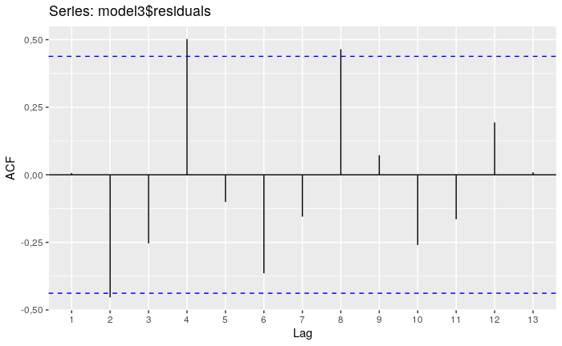

```r
model3 <- Arima(decessi_m_ts, c(0,0,0), c(1, 1, 0, 4), lambda = BoxCox.lambda(decessi_m_ts))
ggAcf(model3$residuals)
```

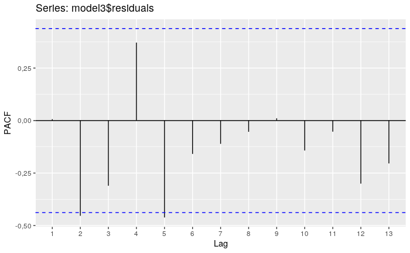

```r
ggPacf(model3$residuals)
```

[figure not shown]

```r
forecast(model3) %>% plot()
```

Piuttosto male. Non possiamo avere conclusioni sensate.

```r
months(time(decessi_m_ts)) %>% factor() -> mesi
mesi_dummy <- dummies::dummy(mesi)
```

```
non-list contrasts argument ignored
```

```r
t <- seq_along(decessi_m_ts)
model2 <- lm(decessi_m_ts ~ mesi_dummy[, -4] + t)
summary(model2)
```

```
Call:
lm(formula = decessi_m_ts ~ mesi_dummy[, -4] + t)

Residuals:
    Min      1Q  Median      3Q     Max
-46,960  -8,713  -0,473   9,168  52,761

Coefficients:
```

```
si è prodotto un NA per coercizione
```

```
                             Estimate Std. Error t value Pr(>|t|)
(Intercept)                  272,2518    14,3113  19,024 6,51e-12 ***
mesi_dummy[, -4]mesiaprile   -21,1698    14,5394  -1,456   0,1660
mesi_dummy[, -4]mesifebbraio  30,4816    14,5394   2,096   0,0534 .
mesi_dummy[, -4]mesigennaio   57,1331    14,6240   3,907   0,0014 **
t                              0,6182     0,9069   0,682   0,5059
---
Signif. codes:  0 ‘***’ 0,001 ‘**’ 0,01 ‘*’ 0,05 ‘.’ 0,1 ‘ ’ 1

Residual standard error: 22,94 on 15 degrees of freedom
Multiple R-squared:  0,6844,    Adjusted R-squared:  0,6002
F-statistic: 8,131 on 4 and 15 DF,  p-value: 0,001075
```

Si osserva che per questo primo modello, la variabile esplicativa t non risulta significativa. Ce lo si aspettava dal fatto che la serie non esibiva un trend evidendente negli anni passati.

```r
model3 <- lm(decessi_m_ts ~ mesi_dummy[, -4])
summary(model3)
```

```
Call:
lm(formula = decessi_m_ts ~ mesi_dummy[, -4])

Residuals:
    Min      1Q  Median      3Q     Max
-49,432  -8,403  -1,882   7,029  52,761

Coefficients:
```

```
si è prodotto un NA per coercizione
```

```
                             Estimate Std. Error t value Pr(>|t|)
(Intercept)                    279,05      10,09  27,662 6,14e-15 ***
mesi_dummy[, -4]mesiaprile     -20,55      14,27  -1,441  0,16899
mesi_dummy[, -4]mesifebbraio    29,86      14,27   2,093  0,05261 .
mesi_dummy[, -4]mesigennaio     55,90      14,27   3,918  0,00123 **
---
Signif. codes:  0 ‘***’ 0,001 ‘**’ 0,01 ‘*’ 0,05 ‘.’ 0,1 ‘ ’ 1

Residual standard error: 22,56 on 16 degrees of freedom
Multiple R-squared:  0,6746,    Adjusted R-squared:  0,6136
F-statistic: 11,06 on 3 and 16 DF,  p-value: 0,0003536
```

Si osserva che la capacità del modello di spiegareì i dati aumenta, anche se di poco.

L’intercetta del modello corrisponde al numero di morti giornalieri che il modello interpreta per il mese di marzo, con la relativa deviazione standard.

Si conclude che:

```r
intercept <- summary(model3)[["coefficients"]][1,1]
std <- summary(model3)[["coefficients"]][1,2]
M_DEATHS_NOCOVID = intercept*31
STD_DEATHS_NOCOVID = std*31
cat("Totale morti previsti per il mese di marzo nel 2020, in assenza di Covid-19: ",
    M_DEATHS_NOCOVID,
    " +- ",
    STD_DEATHS_NOCOVID
    )
```

```
Totale morti previsti per il mese di marzo nel 2020, in assenza di Covid-19:  8650,6  +-  312,7199
```

# Ora si calcolano i morti per covid.

Per prima cosa si legge il dataset con i dati delle morti nei comuni lombardi a marzo.

Si sommano i valori e si ottiene un range.

```r
decessi_covid_comuni <- read_csv("data/comuni_decessi_marzo.csv")
DEATHS_COVID_C_max <- sum(decessi_covid_comuni$DECESSI_HIGH)
DEATHS_COVID_C_min <- sum(decessi_covid_comuni$DECESSI_LOW)
```

Si calcola ora in numero di morti IN PIÙ che ci sono state quest’anno rispetto all’anno scorso.

Il range di valori è calcolato come segue:

```r
DEATHS_PLUS_2020_max <- (DEATHS_COVID_C_max - (M_DEATHS_NOCOVID - STD_DEATHS_NOCOVID)) %>% as.integer()
DEATHS_PLUS_2020_min <- (DEATHS_COVID_C_min - (M_DEATHS_NOCOVID + STD_DEATHS_NOCOVID)) %>% as.integer()
```

Ora il confronto con i dati della protezione civile. Si scaricano i due dataset relativi al primo marzo e al 31 marzo.

```r
data_0301 <- read_csv("https://raw.githubusercontent.com/pcm-dpc/COVID-19/master/dati-regioni/dpc-covid19-ita-regioni-20200301.csv")
data_0331 <- read_csv("https://raw.githubusercontent.com/pcm-dpc/COVID-19/master/dati-regioni/dpc-covid19-ita-regioni-20200331.csv")
deaths_0331 <- data_0331 %>% filter(denominazione_regione == "Lombardia") %>% select(deceduti)
deaths_0301 <- data_0301 %>% filter(denominazione_regione == "Lombardia") %>% select(deceduti)
DEATHS_PR <- as.numeric(deaths_0331 - deaths_0301)
```

Ora plottiamo la situazione:

```r
mean_death_plus <- (DEATHS_PLUS_2020_max + DEATHS_PLUS_2020_min)/2
sd_death_plus <- (DEATHS_PLUS_2020_max - DEATHS_PLUS_2020_min)/2
data <- data.frame(
  name = c("Aumento di decessi in Lombardia nel marzo 2020", "Decessi per COVID-19"),
  value = c(mean_death_plus, DEATHS_PR),
  sd = c(sd_death_plus, 0)
)

ggplot(data) +
    geom_bar( aes(x=name, y=value), stat="identity", fill="skyblue", alpha=0.7) +
    geom_errorbar( aes(x=name, ymin=value-sd, ymax=value+sd), width=0.4, colour="orange", alpha=0.9, size=1.3)
```

[output not shown]

```r
italycoordinates <- read_csv("../../italy cordinates/italy_geo.csv")
names(italycoordinates)[names(italycoordinates) == "comune"] <- "NOME_COMUNE"
italycoordinates
length(unique(italycoordinates$comune))

marzo_2020 <- read.csv("data/comuni_decessi_marzo.csv")
xNew = merge (marzo_2020,italycoordinates, by = "NOME_COMUNE")

xNew <- transform(xNew,longitudine = as.numeric(lng),
                    latitudine = as.numeric(lat))

xNew<- xNew[,-c(6:8)]
write.csv(xNew,"../../italy cordinates/xNew.csv")
```